# PML_Final Project

Marina Makanrova

July 21, 2016

# Synopsis

The data used in this paper was provided by HAR study Velloso, E.; Bulling, A.; Gellersen, H.; Ugulino, W.; Fuks, H. Qualitative Activity Recognition of Weight Lifting Exercises. Proceedings of 4th International Conference in Cooperation with SIGCHI (Augmented Human ’13) . Stuttgart, Germany: ACM SIGCHI, 2013 http://groupware.les.inf.puc-rio.br/har

The goal of the analysis is to to predict the manner in which people who participated in the research did the exercise.

# System settings

The following packages were used during the analysis:

```r
library(caret)
library(randomForest)
library(rpart)
library(rpart.plot)
library(rattle)
library(AppliedPredictiveModeling)
library(forecast)
```

# Original data

The data was provided by the following website http://groupware.les.inf.puc-rio.br/har The data was loaded with the following code:

```r
URLtrain <- "https://d396qusza40orc.cloudfront.net/predmachlearn/pml-training.csv"
URLtest <- "https://d396qusza40orc.cloudfront.net/predmachlearn/pml-testing.csv"
training <- read.csv(URLtrain, na.strings=c("NA","#DIV/0!",""))
testing <- read.csv(URLtest, na.strings=c("NA","#DIV/0!",""))
```

# Data cleaning

The seed was set to 33577

```r
set.seed(33577)
```

First, we cleared the data. We eliminated the columns that contained N/A values and also excluses first 7 columns as they contain information not valuable for prediction (id, username, time and date).

```r
training_cl <- training[,-(1:7)]
training_noNA <- training_cl
#the following code will eliminate all columns with N/A values from training data
for(i in 1:length(training_cl)) {
     if( sum( is.na( training_cl[, i] ) ) / nrow(training_cl) > 0) {
         for(j in 1:length(training_noNA)) {
             if( length( grep(names(training_cl[i]), names(training_noNA)[j]) ) ==1)  {
                 training_noNA <- training_noNA[ , -j]
             }
         }
     }
}
dim(training)
```

```
## [1] 19622   160
```

```r
dim(training_noNA)
```

```
## [1] 19622    53
```

Also, we checked for covariats that have virtually no variablility.

```r
nzv <- nearZeroVar(training_noNA, saveMetrics=TRUE)
nzv
```

```
##                      freqRatio percentUnique zeroVar   nzv
## roll_belt             1.101904     6.7781062   FALSE FALSE
## pitch_belt            1.036082     9.3772296   FALSE FALSE
## yaw_belt              1.058480     9.9734991   FALSE FALSE
## total_accel_belt      1.063160     0.1477933   FALSE FALSE
## gyros_belt_x          1.058651     0.7134849   FALSE FALSE
## gyros_belt_y          1.144000     0.3516461   FALSE FALSE
## gyros_belt_z          1.066214     0.8612782   FALSE FALSE
## accel_belt_x          1.055412     0.8357966   FALSE FALSE
## accel_belt_y          1.113725     0.7287738   FALSE FALSE
## accel_belt_z          1.078767     1.5237998   FALSE FALSE
## magnet_belt_x         1.090141     1.6664968   FALSE FALSE
## magnet_belt_y         1.099688     1.5187035   FALSE FALSE
## magnet_belt_z         1.006369     2.3290184   FALSE FALSE
## roll_arm             52.338462    13.5256345   FALSE FALSE
## pitch_arm            87.256410    15.7323412   FALSE FALSE
## yaw_arm              33.029126    14.6570176   FALSE FALSE
## total_accel_arm       1.024526     0.3363572   FALSE FALSE
## gyros_arm_x           1.015504     3.2769341   FALSE FALSE
## gyros_arm_y           1.454369     1.9162165   FALSE FALSE
## gyros_arm_z           1.110687     1.2638875   FALSE FALSE
## accel_arm_x           1.017341     3.9598410   FALSE FALSE
## accel_arm_y           1.140187     2.7367241   FALSE FALSE
## accel_arm_z           1.128000     4.0362858   FALSE FALSE
## magnet_arm_x          1.000000     6.8239731   FALSE FALSE
## magnet_arm_y          1.056818     4.4439914   FALSE FALSE
## magnet_arm_z          1.036364     6.4468454   FALSE FALSE
## roll_dumbbell         1.022388    84.2065029   FALSE FALSE
## pitch_dumbbell        2.277372    81.7449801   FALSE FALSE
## yaw_dumbbell          1.132231    83.4828254   FALSE FALSE
## total_accel_dumbbell  1.072634     0.2191418   FALSE FALSE
## gyros_dumbbell_x      1.003268     1.2282132   FALSE FALSE
## gyros_dumbbell_y      1.264957     1.4167771   FALSE FALSE
## gyros_dumbbell_z      1.060100     1.0498420   FALSE FALSE
## accel_dumbbell_x      1.018018     2.1659362   FALSE FALSE
## accel_dumbbell_y      1.053061     2.3748853   FALSE FALSE
## accel_dumbbell_z      1.133333     2.0894914   FALSE FALSE
## magnet_dumbbell_x     1.098266     5.7486495   FALSE FALSE
## magnet_dumbbell_y     1.197740     4.3012945   FALSE FALSE
## magnet_dumbbell_z     1.020833     3.4451126   FALSE FALSE
## roll_forearm         11.589286    11.0895933   FALSE FALSE
## pitch_forearm        65.983051    14.8557741   FALSE FALSE
## yaw_forearm          15.322835    10.1467740   FALSE FALSE
## total_accel_forearm   1.128928     0.3567424   FALSE FALSE
## gyros_forearm_x       1.059273     1.5187035   FALSE FALSE
## gyros_forearm_y       1.036554     3.7763735   FALSE FALSE
## gyros_forearm_z       1.122917     1.5645704   FALSE FALSE
## accel_forearm_x       1.126437     4.0464784   FALSE FALSE
## accel_forearm_y       1.059406     5.1116094   FALSE FALSE
## accel_forearm_z       1.006250     2.9558659   FALSE FALSE
## magnet_forearm_x      1.012346     7.7667924   FALSE FALSE
## magnet_forearm_y      1.246914     9.5403119   FALSE FALSE
## magnet_forearm_z      1.000000     8.5771073   FALSE FALSE
## classe                1.469581     0.0254816   FALSE FALSE
```

Since all the near zero variance variables showed FALSE we didn’t eliminate any covariates.

# Creation of training and testing sets

Then we splitted final training set into 3 training and 3 testing sets.

```r
set.seed(33577)
#created 3 groups of entries
No_set1 <- createDataPartition(training_noNA$classe, p = 1/3, list = FALSE)
set1 <- training_noNA[No_set1,]
training_left <- training_noNA[-No_set1,]
No_set2 <- createDataPartition(training_left $classe, p = 1/2, list = FALSE)
set2 <- training_left[No_set2,]
set3 <- training_left[-No_set2,]
#splited each group into training (60%) and testing (40%) sets
inTrain <- createDataPartition(set1$classe, p=0.6, list=FALSE)
train1 <- set1[inTrain,]
test1 <- set1[-inTrain,]
inTrain <- createDataPartition(set2$classe, p=0.6, list=FALSE)
train2 <- set2[inTrain,]
test2 <- set2[-inTrain,]
inTrain <- createDataPartition(set3$classe, p=0.6, list=FALSE)
train3 <- set3[inTrain,]
test3 <- set3[-inTrain,]
```

# Testing prediction algorithms

As mentioned in the ‘Practical Machine Learning’ course, prediction methods that are used most are classification trees and random forests. We decided to use these two methods in our analysis.

## Classification tree

First, we fitted the first training set with classification tree method and predicted classe for first testing set.

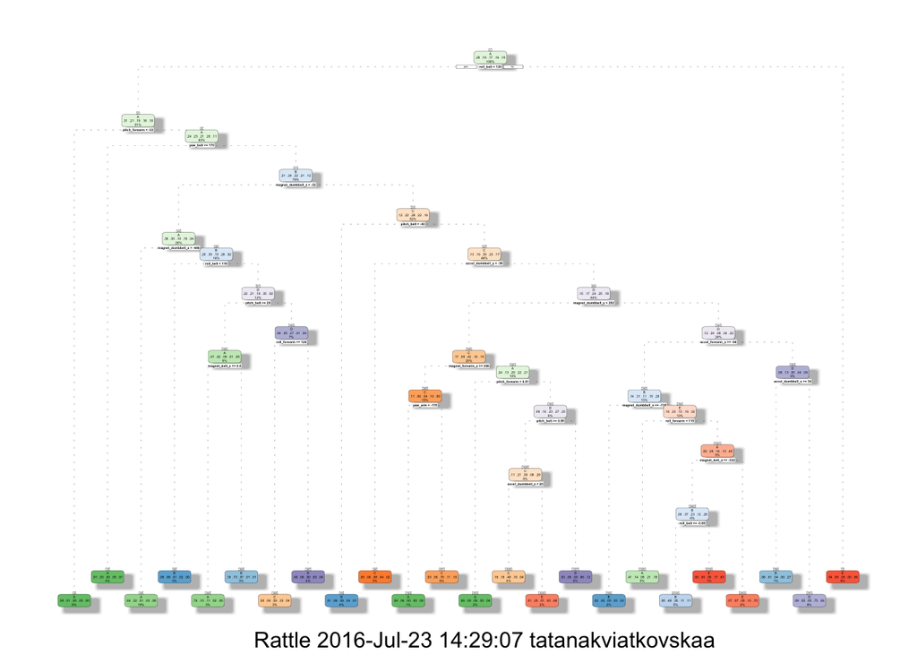

```r
model_CT <- rpart(classe ~ ., data = train1, method = "class")
fancyRpartPlot(model_CT)
```

```r
predict_CT <- predict(model_CT, newdata = test1, , type = "class")
confusionMatrix(predict_CT, test1$classe)
```

```
## Confusion Matrix and Statistics
##
##           Reference
## Prediction   A   B   C   D   E
##          A 632  82  28  44  58
##          B  29 338  50  12  35
##          C  34  48 372  81  38
##          D  29  21   4 274  29
##          E  20  17   2  17 321
##
## Overall Statistics
##
##                Accuracy : 0.7407
##                  95% CI : (0.7235, 0.7574)
##     No Information Rate : 0.2845
##     P-Value [Acc > NIR] : < 2.2e-16
##
##                   Kappa : 0.6705
##  Mcnemar's Test P-Value : < 2.2e-16
##
## Statistics by Class:
##
##                      Class: A Class: B Class: C Class: D Class: E
## Sensitivity            0.8495   0.6680   0.8158   0.6402   0.6674
## Specificity            0.8867   0.9403   0.9069   0.9620   0.9738
## Pos Pred Value         0.7488   0.7284   0.6492   0.7675   0.8515
## Neg Pred Value         0.9368   0.9219   0.9589   0.9318   0.9285
## Prevalence             0.2845   0.1935   0.1744   0.1637   0.1839
## Detection Rate         0.2417   0.1293   0.1423   0.1048   0.1228
## Detection Prevalence   0.3228   0.1774   0.2191   0.1365   0.1442
## Balanced Accuracy      0.8681   0.8041   0.8613   0.8011   0.8206
```

```r
model_CT2 <- rpart(classe ~ ., data = train2, method = "class")
predict_CT2 <- predict(model_CT2, newdata = test2, , type = "class")
confusionMatrix(predict_CT2, test2$classe)
```

```
## Confusion Matrix and Statistics
##
##           Reference
## Prediction   A   B   C   D   E
##          A 679 116  11  35  15
##          B  13 233  20   8   5
##          C  12  76 356  33  37
##          D  29  48  69 318  48
##          E  11  33   0  34 375
##
## Overall Statistics
##
##                Accuracy : 0.7502
##                  95% CI : (0.7331, 0.7667)
##     No Information Rate : 0.2846
##     P-Value [Acc > NIR] : < 2.2e-16
##
##                   Kappa : 0.683
##  Mcnemar's Test P-Value : < 2.2e-16
##
## Statistics by Class:
##
##                      Class: A Class: B Class: C Class: D Class: E
## Sensitivity            0.9126  0.46047   0.7807   0.7430   0.7812
## Specificity            0.9053  0.97818   0.9268   0.9113   0.9634
## Pos Pred Value         0.7932  0.83513   0.6926   0.6211   0.8278
## Neg Pred Value         0.9630  0.88308   0.9524   0.9477   0.9514
## Prevalence             0.2846  0.19357   0.1744   0.1637   0.1836
## Detection Rate         0.2598  0.08914   0.1362   0.1217   0.1435
## Detection Prevalence   0.3275  0.10673   0.1966   0.1959   0.1733
## Balanced Accuracy      0.9090  0.71933   0.8537   0.8271   0.8723
```

95% confidence interval for both groups is quite low, so we decided to fit the data with ‘random forest’ method.

## Random forest

We fitted training set 1 with random forest method and predicted class variable values for testing set 1.

```r
model_RF <- randomForest(classe ~ ., data = train1)
predict_RF <- predict(model_RF, newdata = test1, , type = "class")
confusionMatrix(predict_RF, test1$classe)
```

```
## Confusion Matrix and Statistics
##
##           Reference
## Prediction   A   B   C   D   E
##          A 733   5   0   0   0
##          B   4 498  12   0   0
##          C   5   3 441  14   0
##          D   2   0   3 414   4
##          E   0   0   0   0 477
##
## Overall Statistics
##
##                Accuracy : 0.9801
##                  95% CI : (0.974, 0.9851)
##     No Information Rate : 0.2845
##     P-Value [Acc > NIR] : < 2.2e-16
##
##                   Kappa : 0.9749
##  Mcnemar's Test P-Value : NA
##
## Statistics by Class:
##
##                      Class: A Class: B Class: C Class: D Class: E
## Sensitivity            0.9852   0.9842   0.9671   0.9673   0.9917
## Specificity            0.9973   0.9924   0.9898   0.9959   1.0000
## Pos Pred Value         0.9932   0.9689   0.9525   0.9787   1.0000
## Neg Pred Value         0.9941   0.9962   0.9930   0.9936   0.9981
## Prevalence             0.2845   0.1935   0.1744   0.1637   0.1839
## Detection Rate         0.2803   0.1904   0.1686   0.1583   0.1824
## Detection Prevalence   0.2822   0.1966   0.1771   0.1618   0.1824
## Balanced Accuracy      0.9913   0.9883   0.9785   0.9816   0.9958
```

This time accuracy is much higher. We wanted to check accuracy rate with 2 groups of training and testing sets left. Group 2: training set 2, testing set 2.

```r
model_RF2 <- randomForest(classe ~ ., data = train2)
predict_RF2 <- predict(model_RF2, newdata = test2, , type = "class")
confusionMatrix(predict_RF2, test2$classe)
```

```
## Confusion Matrix and Statistics
##
##           Reference
## Prediction   A   B   C   D   E
##          A 743  17   0   0   0
##          B   1 483  18   0   0
##          C   0   6 432  15   4
##          D   0   0   6 411   6
##          E   0   0   0   2 470
##
## Overall Statistics
##
##                Accuracy : 0.9713
##                  95% CI : (0.9642, 0.9774)
##     No Information Rate : 0.2846
##     P-Value [Acc > NIR] : < 2.2e-16
##
##                   Kappa : 0.9637
##  Mcnemar's Test P-Value : NA
##
## Statistics by Class:
##
##                      Class: A Class: B Class: C Class: D Class: E
## Sensitivity            0.9987   0.9545   0.9474   0.9603   0.9792
## Specificity            0.9909   0.9910   0.9884   0.9945   0.9991
## Pos Pred Value         0.9776   0.9622   0.9453   0.9716   0.9958
## Neg Pred Value         0.9995   0.9891   0.9889   0.9922   0.9953
## Prevalence             0.2846   0.1936   0.1744   0.1637   0.1836
## Detection Rate         0.2842   0.1848   0.1653   0.1572   0.1798
## Detection Prevalence   0.2907   0.1920   0.1748   0.1618   0.1806
## Balanced Accuracy      0.9948   0.9728   0.9679   0.9774   0.9891
```

Group 3: training set 3, testing set 3.

```r
model_RF3 <- randomForest(classe ~ ., data = train3)
predict_RF3 <- predict(model_RF3, newdata = test3, , type = "class")
confusionMatrix(predict_RF3, test3$classe)
```

```
## Confusion Matrix and Statistics
##
##           Reference
## Prediction   A   B   C   D   E
##          A 738  12   0   1   0
##          B   3 487  10   0   2
##          C   2   7 444  17   5
##          D   0   0   2 408   3
##          E   1   0   0   2 470
##
## Overall Statistics
##
##                Accuracy : 0.9744
##                  95% CI : (0.9676, 0.9801)
##     No Information Rate : 0.2846
##     P-Value [Acc > NIR] : < 2.2e-16
##
##                   Kappa : 0.9676
##  Mcnemar's Test P-Value : NA
##
## Statistics by Class:
##
##                      Class: A Class: B Class: C Class: D Class: E
## Sensitivity            0.9919   0.9625   0.9737   0.9533   0.9792
## Specificity            0.9930   0.9929   0.9856   0.9977   0.9986
## Pos Pred Value         0.9827   0.9701   0.9347   0.9879   0.9937
## Neg Pred Value         0.9968   0.9910   0.9944   0.9909   0.9953
## Prevalence             0.2846   0.1936   0.1744   0.1637   0.1836
## Detection Rate         0.2823   0.1863   0.1699   0.1561   0.1798
## Detection Prevalence   0.2873   0.1920   0.1817   0.1580   0.1809
## Balanced Accuracy      0.9925   0.9777   0.9797   0.9755   0.9889
```

The random forest method yealded better results, so we decided to use this method for final prediction model.

## Initial Testing set prediction

Firts set model

```r
predict_F1 <- predict(model_RF, newdata = testing, , type = "class")
predict_F1
```

```
##  1  2  3  4  5  6  7  8  9 10 11 12 13 14 15 16 17 18 19 20
##  B  A  B  A  A  E  D  D  A  A  B  C  B  A  E  E  A  B  B  B
## Levels: A B C D E
```

Second set model

```r
predict_F2 <- predict(model_RF2, newdata = testing, , type = "class")
predict_F2
```

```
##  1  2  3  4  5  6  7  8  9 10 11 12 13 14 15 16 17 18 19 20
##  B  A  B  A  A  E  D  D  A  A  B  C  B  A  E  E  A  B  B  B
## Levels: A B C D E
```

Third set model

```r
predict_F3 <- predict(model_RF3, newdata = testing, , type = "class")
predict_F3
```

```
##  1  2  3  4  5  6  7  8  9 10 11 12 13 14 15 16 17 18 19 20
##  B  A  B  A  A  E  D  B  A  A  B  C  B  A  E  E  A  B  B  B
## Levels: A B C D E
```

Also, we decided to use the whole training set to train the model and predict testing values.

```r
model_final <- randomForest(classe ~ ., data = training_noNA)
predict_final <- predict(model_final, newdata = testing, , type = "class")
predict_final
```

```
##  1  2  3  4  5  6  7  8  9 10 11 12 13 14 15 16 17 18 19 20
##  B  A  B  A  A  E  D  B  A  A  B  C  B  A  E  E  A  B  B  B
## Levels: A B C D E
```

# Results

Created ‘random forest’ model predicted the following values for the testing set:

```
##  1  2  3  4  5  6  7  8  9 10 11 12 13 14 15 16 17 18 19 20
##  B  A  B  A  A  E  D  B  A  A  B  C  B  A  E  E  A  B  B  B
## Levels: A B C D E
```